# Coursework Report

*N* removed NAs: 5

*N* removed <18: 28

**Correct typo age:** 20

*N* total clean: 135

| Group | *N* | *M*<sub>age</sub> | % green |
| --- | --- | --- | --- |
| Control | 68 | 20.59 | 55.39 |
| Experim | 67 | 20.64 | 32.84 |

| Gender | *N* | *M*<sub>age</sub> | % green |
| --- | --- | --- | --- |
| Male | 63 | 20.25 | 40.21 |
| Female | 49 | 21.06 | 46.94 |
| Other | 23 | 20.65 | 49.28 |

**Main analysis results**

**car:**  
χ<sup>2</sup>(1) = 0.07, *p* = .786

**cleaner:**  
χ<sup>2</sup>(1) = 24.3, *p* < .001

**dishwasher:**  
χ<sup>2</sup>(1) = 4.78, *p* = .029

[interactive chart not shown]

[figure not shown]

[interactive chart not shown]

# Coursework Report

Analysing Data, Spring 2020

# Methods

## Participants

| Mean Age | Standard Deviation | Minimum Age | Maximum Age |
| --- | --- | --- | --- |
| 20.62 | 1.87 | 18 | 26 |

Table 2: Participant Descriptives by Gender

[output not shown]

## Design

It is conceptually hypothesized that activating status motives promotes green product choices over more luxurious non-green items. The variables included in this research are condition, category, and product. The condition variable was selected for individuals at random and is a factor variable of 2 levels: experimental high-status story, or control story. It acts to distinguish the participant’s choices in this between-subjects design. The category variable is a factor of 2 levels: luxury non-green product, and green product. This variable is measured based on the number of people having either choice of story setting. The product is another factor variable, with 3 levels: car, dishwasher, and cleaner. The interpretation of high or low scores of each product choice in either category is important in helping disprove or accept the hypothesis. For example, higher scores in the experimental condition for green choices can be used as evidence to support the hypothesis. Age and gender were also variables of interest, both acquired through a questionnaire. Age being a numeric variable, and gender being a factor variable of 3 levels: female, male, and other. Both of these variables allow an interpretation of participant tendencies. The operational hypothesis states that an increase in the likelihood of choosing less luxurious, yet more prosocial green products (car, dishwasher, cleaner), should occur upon an activation of status motives. This will be tested statistically using the chi-squared analysis test.

# Results

Table 1: *Frequency of Car Product Choices by Story Category*

Expected Frequencies for Car Product

|  | luxury | green |
| --- | --- | --- |
| control | 38.28 | 29.72 |
| experimental | 37.72 | 29.28 |

Table 2: *Frequency of Dishwasher Product Choices by Story Category*

Expected Frequencies for Dishwasher Product

|  | luxury | green |
| --- | --- | --- |
| control | 38.79 | 29.21 |
| experimental | 38.21 | 28.79 |

Table 3: *Frequency of Cleaner Product Choices by Story Category*

Expected Frequencies for Cleaner Product

[output not shown]

Below are figures of the data involved for each product:

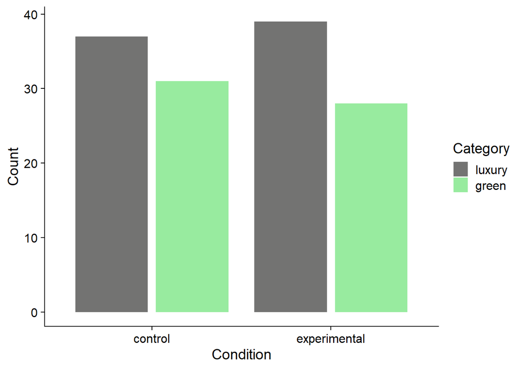

*Figure 1* Frequency of Car Product Choice by Story Category

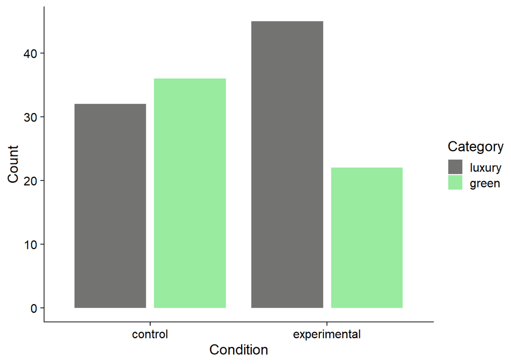

*Figure 2* Frequency of Dishwasher Product Choice by Story Category

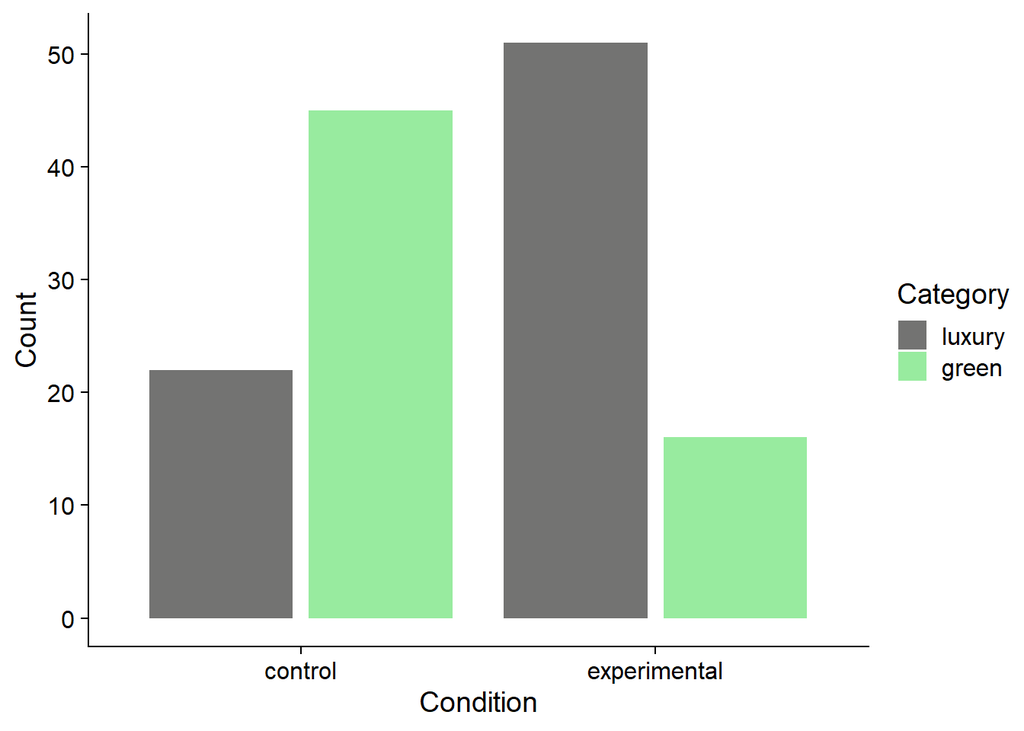

*Figure 3* Frequency of Cleaner Product Choice by Story Category

# Discussion

Basically, the study by Griskevicius et al., (2010) was interested in looking at the increased tendency to choose an altruistic pro-social green product over a luxurious non-green product, in the condition of activating status motives. Although the original study and the current one exhibit a slightly different pattern, it was of interest to compare with other studies as well. Findings by Hartmann & Apaolaza-Ibáñez (2012) support the original study, where status motives may increase green product desire, thus providing a different pattern of results from the current one. The study exposes a sample of consumers to fictitious green energy brand advertisements, to confirm the significance of psychological brand benefits overall (Hartmann & Apaolaza-Ibáñez, 2012). However, their hypothesis on positive influence of self-expressive beliefs on purchase intentions and brand attitudes was not supported (Hartmann & Apaolaza-Ibáñez, 2012). Further research demonstrates that an individual’s intention to engage in conservative and environmentally friendly activities includes an interplay between knowledge, constraints, and motivation (Gkargkavouzi, Halkos, & Matsiori, 2019). Therefore, the studies mentioned do not fully share the same pattern. However, another study by Anderson, Hildreth, & Howland (2015) found that people have a fundamental desire for status, where people were more likely to engage in behaviour that increase their status rather than their social acceptance, even to the point of avoiding the image of conformity. This may be an explanation to why the results in this study showed luxury items scoring higher than green products under the high-status condition and may be seen to support the current results.

Based on the current results, high status does not motivate people to buy green products. The figures show the high-status motive condition scoring higher for luxury products than green products, whereas the control group scored in the opposite manner for the dishwasher and cleaner product. Moreover, the limitations of the study include not testing the participants in either public or private locations, as done in the original. Also, the choices presented to the participants were hypothetical, there were no actual purchases, therefor the results may not reflect realistic data. However, this study employs strengths such as narrowing and specifying the participant age group for accuracy. It further provides descriptives and statistics on each of the products involved in the study; and discusses associations to the original research.

The research question requires further investigation. As suggested by Thiermann & Sheate (2020), pro-environmental actions are strongly associated with feelings of connectedness to nature and empathy. Therefor, it is of interest to consider the role of personality on pro-social green or luxury non-green product choices. For instance, the research could have the participants perform personality tests, then have them allocated in either public or private environments and tested.

In conclusion, high-status motive does not motivate people to buy green products, but a relation still exists. The results of this study differ from the original, in which the control condition had higher scores for the green product over the luxury product. Further research is considered, in which a stronger adherence to the original study is prefered, as well as implementing other factors that play a part in an individual’s choice, such as intentions, personality, knowledge, and constraints.

# References

Anderson, C., Hildreth, J. A. D., & Howland, L. (2015). Is the desire for status a fundamental human motive? A review of the empirical literature. Psychological Bulletin, 141(3), 574–601. https://doi.org/10.1037/a0038781

Gkargkavouzi, A., Halkos, G., & Matsiori, S. (2019). How do motives and knowledge relate to intention to perform environmental behavior? Assessing the mediating role of constraints. Ecological Economics, 165(May), 106394. https://doi.org/10.1016/j.ecolecon.2019.106394

Griskevicius, V., Tybur, J. M., & Van den Bergh, B. (2010). Going Green to Be Seen: Status, Reputation, and Conspicuous Conservation. Journal of Personality and Social Psychology, 98(3), 392–404. https://doi.org/10.1037/a0017346

Hartmann, P., & Apaolaza-Ibáñez, V. (2012). Consumer attitude and purchase intention toward green energy brands: The roles of psychological benefits and environmental concern. Journal of Business Research, 65(9), 1254–1263. https://doi.org/10.1016/j.jbusres.2011.11.001

Thiermann, U. B., & Sheate, W. R. (2020). Motivating individuals for social transition: The 2-pathway model and experiential strategies for pro-environmental behaviour. Ecological Economics, 174(September 2019), 106668. https://doi.org/10.1016/j.ecolecon.2020.106668